# MBS Model Monitoring Report (Repeat/Top Up)

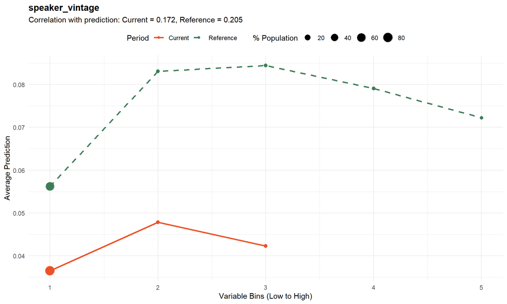

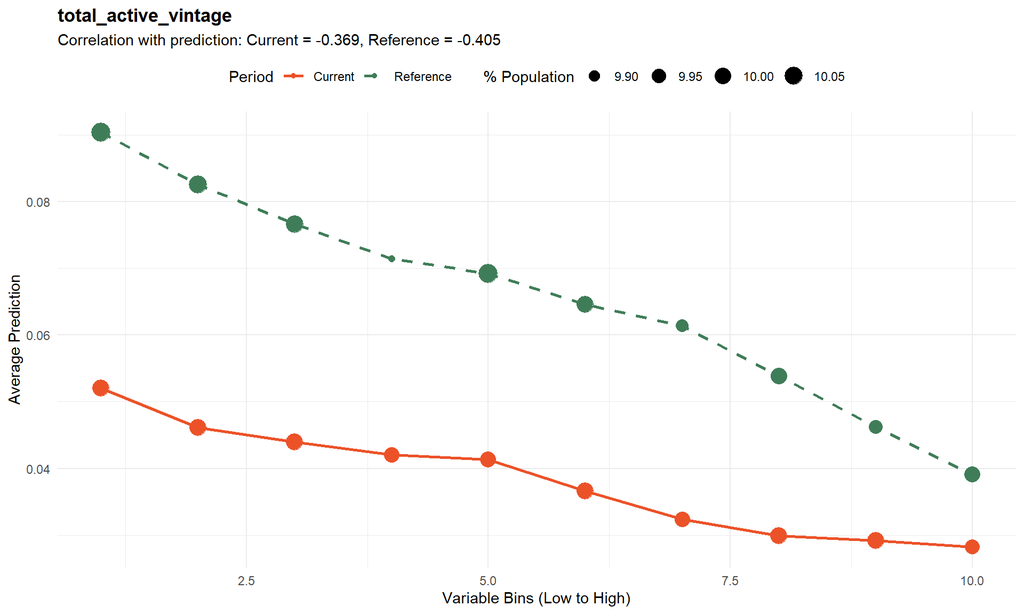

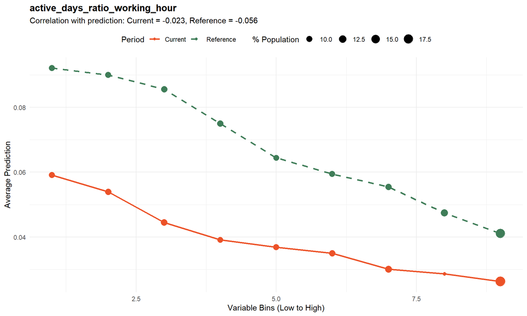

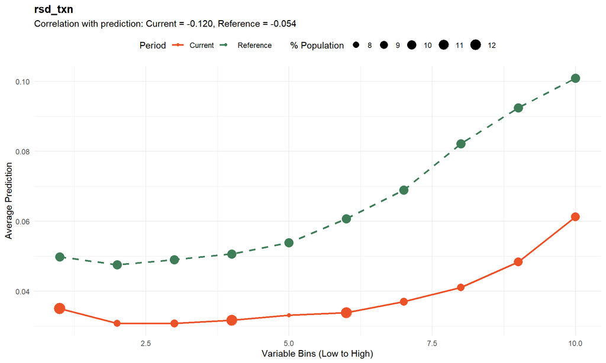

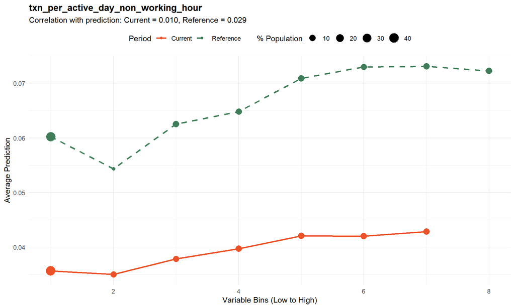

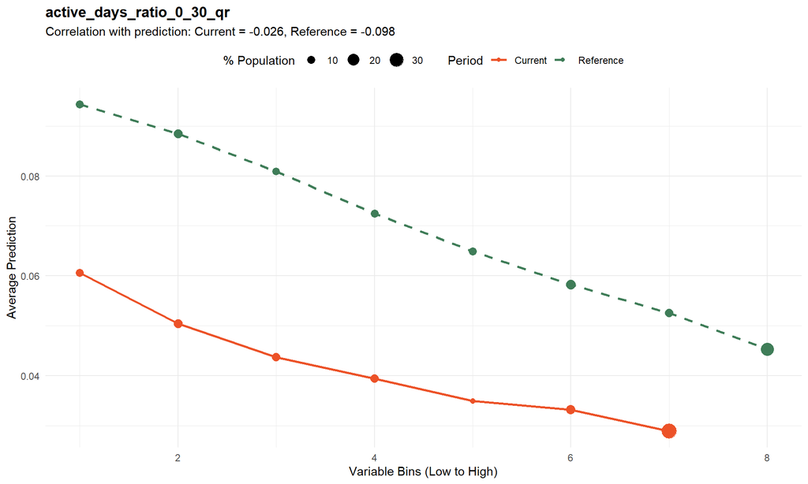

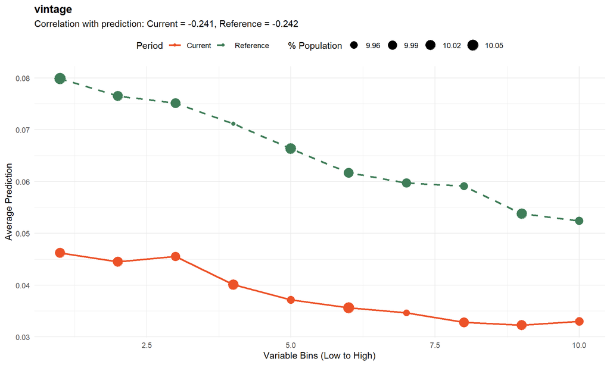

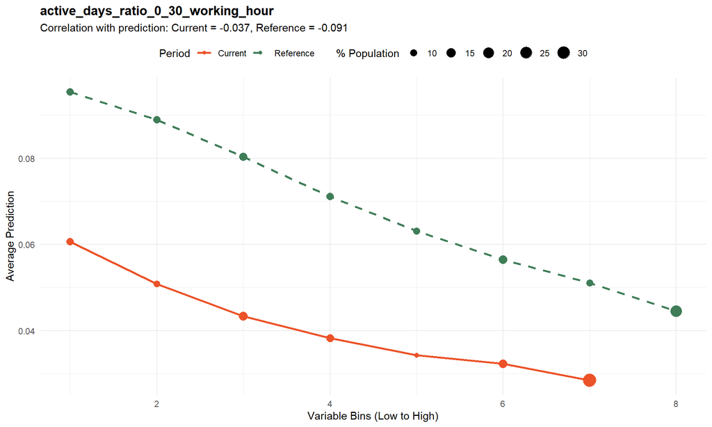

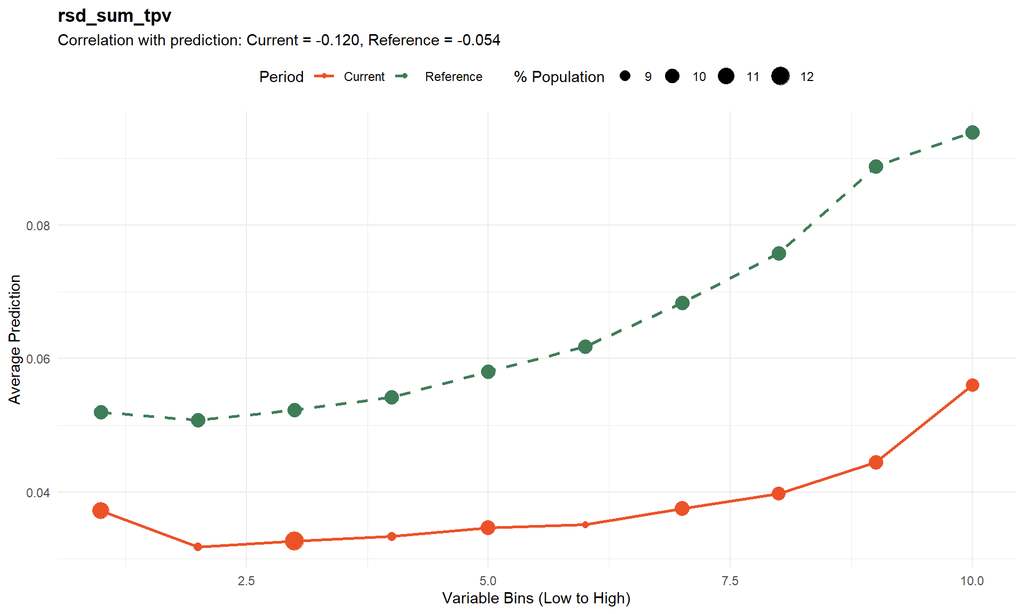

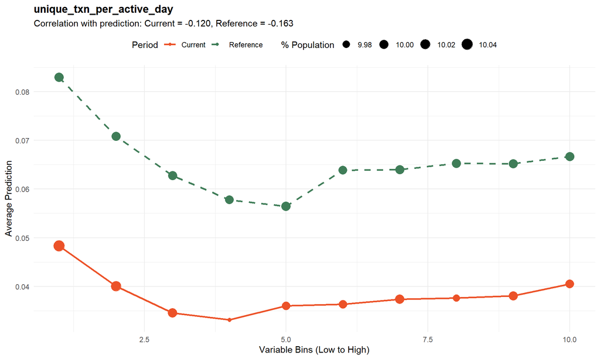

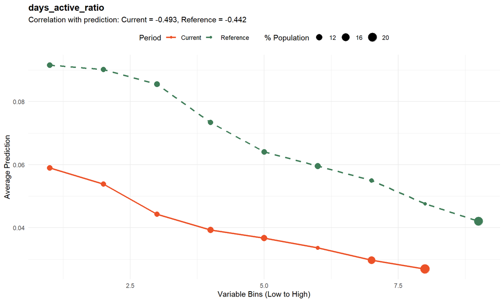

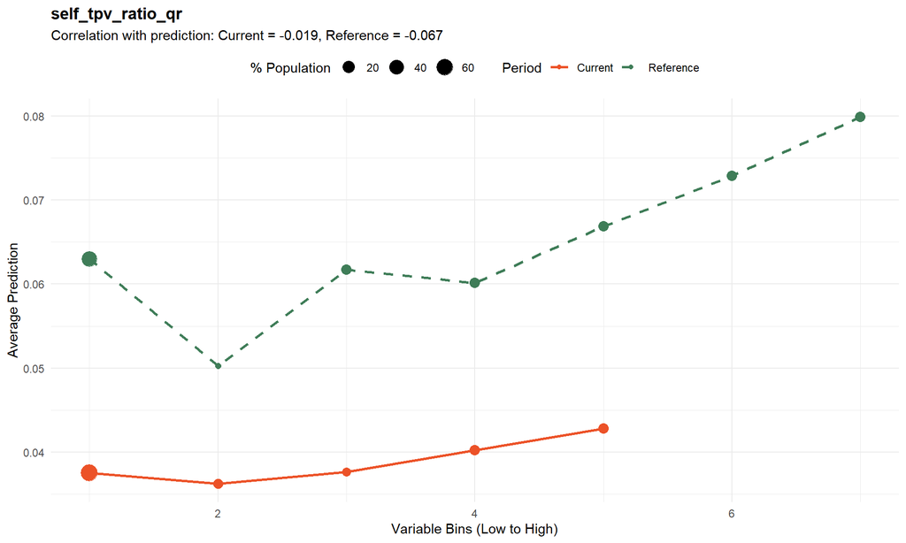

[8 more figures not shown]

```r
# Get top features by correlation
feature_cors <- sapply(features_to_analyze, function(f) {
  abs(cor(current_data[[f]], current_predictions, use = "complete.obs"))
})

# Create impact plots
for(feature in features_to_analyze) {

  if(length(unique(current_data[[feature]])) < 3 || length(unique(current_data[[feature]])) < 3) next

  # Calculate impacts
  current_impact <- analyze_variable_impact(current_data, feature, pred_var)
  reference_impact <- analyze_variable_impact(reference_data, feature, pred_var)

  # Calculate correlations
  cor_current <- cor(current_data[[feature]], current_predictions, use = "complete.obs")
  cor_reference <- cor(reference_data[[feature]], reference_predictions, use = "complete.obs")

  # Create and print plot
  print(plot_variable_impact(current_impact, reference_impact, feature, cor_current, cor_reference))
}
```

## Impact Change Summary

The table below summarizes how variable relationships have changed between periods. Correlation between attributes and predictions are shown below:

```r
# Calculate impact changes
impact_changes <- data.frame(
  Feature = features_to_analyze,
  Current_Correlation = sapply(features_to_analyze, function(f) {
    cor(current_data[[f]], current_predictions, use = "complete.obs", method = "spearman")
  }),
  Reference_Correlation = sapply(features_to_analyze, function(f) {
    cor(reference_data[[f]], reference_predictions, use = "complete.obs", method = "spearman")
  })
) %>%
  mutate(
    Correlation_Change = Current_Correlation - Reference_Correlation,
    Direction_Change = sign(Current_Correlation) != sign(Reference_Correlation),
    Impact_Change_Category = case_when(
      abs(Correlation_Change) < 0.1 ~ "Stable",
      abs(Correlation_Change) < 0.2 ~ "Moderate Change",
      TRUE ~ "Significant Change"
    )
  ) %>%
  arrange(desc(abs(Correlation_Change)))

# Display changes
datatable(
  rownames = F,
  impact_changes,
  options = list(pageLength = 10)
) %>%
  formatRound(columns = c("Current_Correlation", "Reference_Correlation", "Correlation_Change"), digits = 3) %>%
  formatStyle(
    "Impact_Change_Category",
    backgroundColor = styleEqual(
      c("Stable", "Moderate Change", "Significant Change"),
      c("#d4edda", "#fff3cd", "#f8d7da")
    )
  ) %>%
  formatStyle(
    "Direction_Change",
    backgroundColor = styleEqual(c(TRUE, FALSE), c("#f8d7da", "white"))
  )
```

| Feature | Current_Correlation | Reference_Correlation | Correlation_Change | Direction_Change | Impact_Change_Category |
| --- | --- | --- | --- | --- | --- |
| rsd_sum_tpv | 0.2397014615432265 | 0.3974741077159871 | -0.1577726461727606 | False | Moderate Change |
| rsd_txn | 0.3425538899929166 | 0.4904284798527972 | -0.1478745898598807 | False | Moderate Change |
| speaker_vintage | 0.2098814807488313 | 0.2781261123607337 | -0.06824463161190236 | False | Stable |
| avg_ticket_value_qr | -0.120823650271949 | -0.06303334640881726 | -0.05779030386313178 | False | Stable |
| unique_txn_per_active_day | -0.07837595107404047 | -0.1350088001389253 | 0.0566328490648848 | False | Stable |
| avg_ticket_value_30_60_qr | -0.1632638965912002 | -0.1130925745168696 | -0.0501713220743306 | False | Stable |
| self_tpv_ratio_qr | 0.06492343019348724 | 0.1111936913425463 | -0.04627026114905905 | False | Stable |
| shift_txn_m1_m2 | -0.1020942975027971 | -0.06906297159953048 | -0.03303132590326661 | False | Stable |
| shift_txn_m1_m3 | -0.1297835307894884 | -0.0992911583013296 | -0.03049237248815882 | False | Stable |
| total_active_vintage | -0.4372171457183965 | -0.4659673035116201 | 0.0287501577932236 | False | Stable |

[output cut: 11 more lines]

### Interpretation Guidelines:

1. **Relationship Direction**:
- Positive correlation: Higher variable values predict higher risk
- Negative correlation: Higher variable values predict lower risk

**Note** that `spearman` correlation is used to mitigate the impact to significant spread if any.

2. **Impact Strength**:
- Higher values indicate stronger variable influence
- Lower values suggest limited impact on predictions
3. **Changes to Monitor**:
- Direction changes (sign flips) require immediate investigation
- Significant correlation changes may indicate population shifts
- Different shapes between periods suggest relationship changes